# assignment

Charles Cheruparambil

2023-03-16

```r
setwd("~/Documents/ETH/MSc HST/Bioinformatic Approaches to Regulatory Genomics and Epigenomics/week 3")
install.packages("dbplyr", repos = "http://cran.us.r-project.org")
install.packages("rlang", repos = "http://cran.us.r-project.org")
if (!require("BiocManager", quietly = TRUE))
    install.packages("BiocManager")
BiocManager::install("Rsubread")
if (!require("BiocManager", quietly = TRUE))
    install.packages("BiocManager")

BiocManager::install("Rfastp")
suppressPackageStartupMessages({
  library(AnnotationHub)
  library(Rsubread)
  library(rtracklayer)
  library(Biostrings)
  library(Rfastp)
  library(epiwraps)
})
ah <- AnnotationHub()
```

```
## snapshotDate(): 2022-10-31
```

Download the following Drosophila ChIP-seq for the protein CTCF and go through primary analysis:

```r
options(timeout=3600)
dir.create("raw")
download.file("https://www.encodeproject.org/files/ENCFF127RRR/@@download/ENCFF127RRR.fastq.gz", dest="raw/CTCF.fastq.gz")
```

## Using Rfastp for ‘raw reads’

```r
dir.create("rfastp.trimmed")
qc <- lapply(c(CTCF="raw/CTCF.fastq.gz"), FUN=function(x){
  Rfastp::rfastp(x, thread=4, overrepresentationAnalysis=TRUE,
                 outputFastq=file.path("rfastp.trimmed/",gsub("\\.fastq\\.gz$","",basename(x))))
})
```

This will create an html report with before/after QC plots, as well as a trimmed and filtered fastq file. Furthermore, the R output object (equivalent to the .json stats also saved by the program) can be used to generate the QC plots inside a markdown, for example:

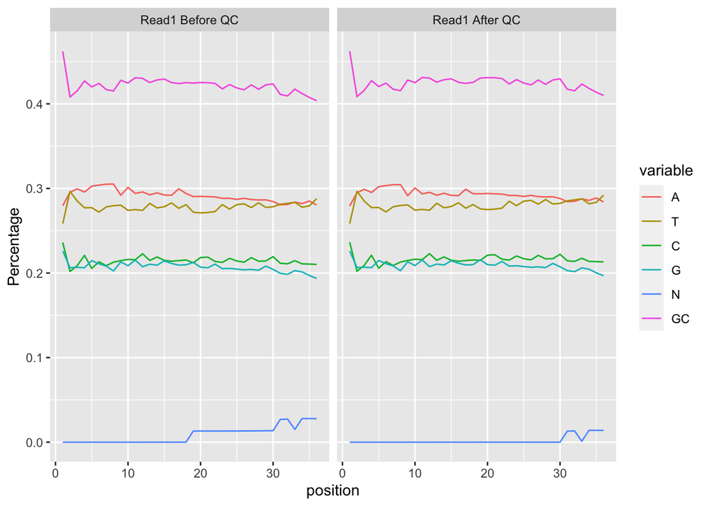

```r
Rfastp::curvePlot(qc$CTCF, curve="content_curves")
```

# Alignment

## Using Rsubread

### Building a genome index for mapping

This we have to do only once for a genome, and can then re-use across projects

```r
# we get the genome sequence from AnnotationHub
genome <- ah[["AH49674"]]
# we create a new directory that will contain the genome index
dir.create("BDGP6_genome")
# we write the genome sequence in fasta format
export(import.2bit(genome), "BDGP6_genome/genome.fasta.gz", compress=TRUE)
# we build a Rsubread index
Rsubread::buildindex("BDGP6_genome/rsubread", reference="BDGP6_genome/genome.fasta.gz")
```

### Alignment

```r
dir.create('aligned')
```

```r
align.stats <- Rsubread::align(index="BDGP6_genome/rsubread", type="dna",
                               readfile1=c("raw/CTCF.fastq.gz"),
                               output_file=c("aligned/CTCF.bam"),
                               nthreads=6, sortReadsByCoordinates=TRUE)
```

[output not shown]

[output cut: 26 more lines]

```
##
## //================================   Summary =================================\\
## ||                                                                            ||
## ||                 Total reads : 3,884,614                                    ||
## ||                      Mapped : 3,515,416 (90.5%)                            ||
## ||             Uniquely mapped : 3,057,440                                    ||
## ||               Multi-mapping : 457,976                                      ||
## ||                                                                            ||
## ||                    Unmapped : 369,198                                      ||
## ||                                                                            ||
## ||                      Indels : 1,860                                        ||
## ||                                                                            ||
## ||                Running time : 3.5 minutes                                  ||
## ||                                                                            ||
## \\============================================================================//
```

```r
align.stats
```

```
##                       CTCF.bam
## Total_reads            3884614
## Mapped_reads           3515416
## Uniquely_mapped_reads  3057440
## Multi_mapping_reads     457976
## Unmapped_reads          369198
## Indels                    1860
```

Based on this table, we can see that out of the total 3,884,614 reads generated, 3,515,416 reads were successfully mapped to the reference genome or transcriptome. Among the mapped reads, 3,057,440 reads were uniquely mapped to a single location in the reference genome or transcriptome, while 457,976 reads mapped to multiple locations. Additionally, 369,198 reads could not be aligned to the reference genome or transcriptome. The table also indicates that there were 1,860 indels found in the aligned reads compared to the reference genome or transcriptome.

Overall, this table provides information on the quality of the alignment of sequencing reads to the reference genome or transcriptome, which is an essential step in many genomic analyses, such as gene expression profiling, variant calling, and genome assembly.

## Using R

This alternative is currently still very beta when it comes to using the input control, so here we will do without it. For the purpose of this course, this is offered as an alternative for windows users who can’t install MACS2/3:

```r
peaks <- callPeaks("aligned/CTCF.bam", fragLength=50L)
```

```
## Reading signal and identifying candidate regions...
```

```
## Reading signal coverage...
```

```
## 44177 initial candidate regions
```

```
## Getting strand information
```

```
## 11139 peaks after filtering
```

```
## Reading signal coverage...
```

```
## 24129 initial candidate regions
```

```
## Getting strand information
```

```
## 5784 peaks after filtering
```

```
## Reading signal coverage...
```

```
## 23692 initial candidate regions
```

```
## Getting strand information
```

```
## 5955 peaks after filtering
```

```
## Reading signal coverage...
```

```
## 15693 initial candidate regions
```

```
## Getting strand information
```

```
## 4038 peaks after filtering
```

```
## Identified 26916 candidate regions
```

```
## Computing significance...
```

```
## (In the absence of a control, FDR is unlikely to be calibrated)
```

```
## Reporting 2873 regions, 1622 with FDR<0.05
```

```r
# if we want to save it as a bed file:
dir.create('peaks')
rtracklayer::export.bed(peaks, "peaks/peaks.bed")
```

Overall, this type of analysis is useful for identifying regions of the genome that are involved in specific biological processes or diseases and can help researchers gain a better understanding of the underlying mechanisms. However, it is important to note that this analysis only identifies candidate regions and further experiments or functional studies are required to confirm their biological relevance.

```r
head(peaks)
```

```
## GRanges object with 6 ranges and 9 metadata columns:
##       seqnames      ranges strand |  maxCount meanCount    maxPos    maxNeg
##          <Rle>   <IRanges>  <Rle> | <integer> <numeric> <integer> <integer>
##   [1]       2L   1647-1674      * |        14   14.0000         9         5
##   [2]       2L   1799-1824      * |        15   15.0000         8         7
##   [3]       2L   3148-3174      * |        25   25.0000        11        14
##   [4]       2L   3599-3625      * |        27   27.0000        12        15
##   [5]       2L   4048-4075      * |        21   21.0000        13         8
##   [6]       2L 21363-21498      * |        22   14.0368         9        14
##              bg   log10FE    log10p  log10FDR     score
##       <numeric> <integer> <numeric> <numeric> <integer>
##   [1]   1.64775        75      3.23      0.00       493
##   [2]   1.68360        78      4.99      0.59       513
##   [3]   1.56642       101      9.08      4.67       664
##   [4]   1.53083       104     10.20      5.78       684
##   [5]   1.54288        94      5.95      1.54       618
##   [6]   1.84980        72      6.95      2.54       474
##   -------
##   seqinfo: 1870 sequences from an unspecified genome; no seqlengths
```

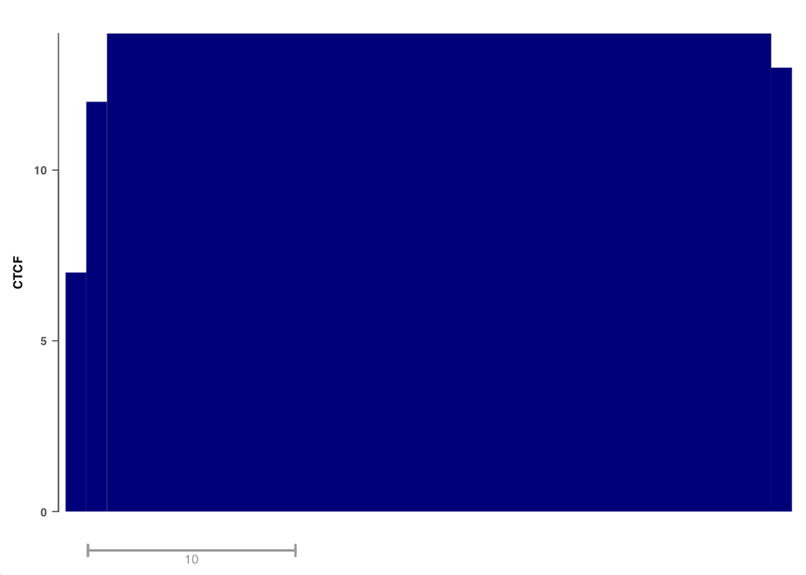

```r
region <- as.character(granges(peaks[1]))
plotSignalTracks(c(CTCF="aligned/CTCF.bam"), region=region)
```